# OTX2 TFBS deletion analysis

Pierre Murat

02 January, 2025

This note book reports the analysis of the OTX2 TFBD deletion experiment

```r
setwd("/lustre/scratch126/gengen/projects/escramble")
```

# 1 maxATAC

## 1.1 ATAC-seq processing

Transcription factor (TF) binding prediction from ATAC-seq signal and DNA sequence is performed with maxATAC (https://github.com/MiraldiLab/maxATAC). maxATAC makes TF binding site (TFBS) predictions at 32 bp resolution.

We use publicly available HAP-1 ATAC-seq data from: Schick S, Rendeiro AF, Runggatscher K, Ringler A et al. Systematic characterization of BAF mutations provides insights into intracomplex synthetic lethalities in human cancers. Nat Genet 2019 Sep;51(9):1399-1410. PMID: 31427792

an available at: https://www.ncbi.nlm.nih.gov/geo/query/acc.cgi?acc=GSE108390

download data for GSM2897141:ATAC-seq_HAP1_WT_r1_C631 (SRR6410048) and GSM2897142:ATAC-seq_HAP1_WT_r2_C631 (SRR6410049) from SRA using SRA toolkit

```bash
# bash, run locally
cd /Users/pm23/Desktop/Projects/EnhancerScramble/Dataset/GSE108386
/Users/pm23/Desktop/Software/SRA_Toolkit/sratoolkit.3.1.1-mac-x86_64/bin/fasterq-dump SRR6410048 -O /Users/pm23/Desktop/Projects/EnhancerScramble/Dataset/GSE108386
/Users/pm23/Desktop/Software/SRA_Toolkit/sratoolkit.3.1.1-mac-x86_64/bin/fasterq-dump SRR6410049 -O /Users/pm23/Desktop/Projects/EnhancerScramble/Dataset/GSE108386
# Upload data to farm
scp -r /Users/pm23/Desktop/Projects/EnhancerScramble/Dataset/GSE108386 farm:/lustre/scratch126/gengen/projects/escramble/Dataset
# Data was deleted
```

Combine reads for both duplicates and align

```bash
# FARM

# Combine replicate
cd /lustre/scratch126/gengen/projects/escramble/Dataset/GSE108386
cat SRR6410048_1.fastq SRR6410049_1.fastq > HAP1.ATAC.seq_1.fastq
cat SRR6410048_2.fastq SRR6410049_2.fastq > HAP1.ATAC.seq_2.fastq

# Read statistics
bsub -q normal -n 16 -R'select[mem>32000] rusage[mem=32000]' -M 32000 -o seqkit.stats.log \
'seqkit stats HAP1.ATAC.seq_1.fastq > HAP1.ATAC.seq_1_stats.txt
seqkit stats HAP1.ATAC.seq_2.fastq > HAP1.ATAC.seq_2_stats.txt'
# 91,649,894 reads

# Align, sort and compute coverage file
bsub -q normal -n 12 -R'select[mem>32000] rusage[mem=32000] span[hosts=1]' -M32000 -o bwa_mem.log -J bwa \
'bwa mem -t 12 /lustre/scratch126/gengen/teams/parts/pm23/Genomes/hg38/hg38.fa.gz HAP1.ATAC.seq_1.fastq HAP1.ATAC.seq_2.fastq > HAP1.ATAC.seq.sam
samtools sort -@ 12 -m 2G HAP1.ATAC.seq.sam -o HAP1.ATAC.seq.bam
samtools index -@ 12 HAP1.ATAC.seq.bam
bamCoverage -p 12 -bs 100 --normalizeUsing CPM -b HAP1.ATAC.seq.bam -o HAP1.ATAC.seq.bw'

scp farm:/lustre/scratch126/gengen/projects/escramble/Dataset/GSE108386/HAP1.ATAC.seq.bw /Users/pm23/Desktop/Projects/EnhancerScramble/Dataset/GSE108386
```

Prepare the ATAC-seq signal with maxATAC prepare

```bash
# FARM

conda activate maxatac

bsub -q normal -n 12 -R'select[mem>32000] rusage[mem=32000] span[hosts=1]' -M32000 -o /lustre/scratch126/gengen/projects/escramble/Data/maxatac/maxatac_prepare/maxatac_prepare.log -J maxatac_prepare \
'maxatac prepare -t 12 \
-i /lustre/scratch126/gengen/projects/escramble/Dataset/GSE108386/HAP1.ATAC.seq.bam \
-o /lustre/scratch126/gengen/projects/escramble/Data/maxatac/maxatac_prepare -prefix HAP1'

scp farm:/lustre/scratch126/gengen/projects/escramble/Data/maxatac/maxatac_prepare/HAP1_IS_slop20_RP20M_minmax01.bw /Users/pm23/Desktop/Projects/EnhancerScramble/Dataset/GSE108386
```

Call ATAC-seq peaks

ATAC peaks are called with the bdgpeakcall function of MACS2 with previously generated bedgraph files using the nucleosome depleted data

```bash
# FARM

module load HGI/softpack/groups/escramble/eSCRAMBLE/6
conda activate bigwigtowig

# Convert ATAC-seq bigwig to bedgraph

bsub -q normal -n 4 -R'select[mem>32000] rusage[mem=32000]' -M 32000 -o /lustre/scratch126/gengen/projects/escramble/Dataset/GSE108386/bigWigToBedGraph.log \
'conda_env="/software/hgi/envs/conda/team227/pm23/bigwigtowig"
    source /software/hgi/installs/conda-audited/miniconda/bin/activate $conda_env
bigWigToBedGraph /lustre/scratch126/gengen/projects/escramble/Dataset/GSE108386/HAP1.ATAC.seq.bw /lustre/scratch126/gengen/projects/escramble/Dataset/GSE108386/HAP1.ATAC.seq.bedGraph'

# Call peaks

bsub -q normal -n 12 -R'select[mem>32000] rusage[mem=32000]' -M 32000 \
-o /lustre/scratch126/gengen/projects/escramble/Dataset/GSE108386/macs2.log \
'macs2 bdgpeakcall -i /lustre/scratch126/gengen/projects/escramble/Dataset/GSE108386/HAP1.ATAC.seq.bedGraph \
--cutoff 0.1 --max-gap 100 --min-length 50 \
-o /lustre/scratch126/gengen/projects/escramble/Dataset/GSE108386/macs2/HAP1.ATAC.seq.c0_1.mg100.ml50.peaks'

# FINAL PARAMETERS
# cutoff 0.1, max-gap 100 and min-length 50
```

Convert macs2 peak files into bed files

```r
# R

# List files
peak.file <- list.files("/lustre/scratch126/gengen/projects/escramble/Dataset/GSE108386/macs2/")
peak.file <- peak.file[grepl(".peaks$", peak.file)]
peak.path <- paste0("/lustre/scratch126/gengen/projects/escramble/Dataset/GSE108386/macs2/", peak.file)

# Format and save bed files
for (i in 1:length(peak.path)) {
  file.id.i <- peak.file[i]
  peaks.i <- read.table(peak.path[i], sep = "\t", skip = 1) %>% dplyr::select(V1, V2, V3, V5, V10)
  path.i <- paste0(peak.path[i], ".bed")
  write.table(peaks.i, path.i, sep="\t", col.names = F, row.names = F, quote = F)
}
```

Filter macs2 peaks

```r
# R

HAP1.ATAC.macs2.peak.df <- read.table("/lustre/scratch126/gengen/projects/escramble/Dataset/GSE108386/macs2/HAP1.ATAC.seq.c0_1.mg100.ml50.peaks", sep = "\t", skip = 1) %>% dplyr::select(V1, V2, V3, V5, V10)
colnames(HAP1.ATAC.macs2.peak.df) <- c("seqnames", "start", "end", "peak.pos", "score")
HAP1.ATAC.macs2.peak.df <- HAP1.ATAC.macs2.peak.df %>% mutate(peak.width = end - start) # 795,775 peaks

# Filter peaks on width (>= 500)
HAP1.ATAC.macs2.peak.filter.df <- HAP1.ATAC.macs2.peak.df %>% filter(peak.width >= 500 & peak.width <= 10000) # 95,492 peaks

# Filter peaks on score (>= 250)
HAP1.ATAC.macs2.peak.filter.df <- HAP1.ATAC.macs2.peak.filter.df %>% filter(score >= 250) # 72,705 peaks

# Save
write.table(HAP1.ATAC.macs2.peak.filter.df, "/lustre/scratch126/gengen/projects/escramble/Dataset/GSE108386/macs2/HAP1.ATAC.seq.peaks.bed", sep="\t", col.names = F, row.names = F, quote = F)
```

## 1.2 OTX2 super-enhancer

Predict TF binding within OTX2 domain (chr14:56,600,000-57,100,000)

Prepare bed file for ROI

```r
# R
OTX2.bed <- cbind.data.frame(seqnames = "chr14", start = 56600000, end = 57100000)
write.table(OTX2.bed, "/lustre/scratch126/gengen/projects/escramble/Data/maxatac/OTX2/OTX2.bed", sep="\t", col.names = F, row.names = F, quote = F)
```

List available models

```r
# R

library(tidyr)

maxATAC.models <- list.files("~/opt/maxatac/data/models")
# Models
paste0(maxATAC.models, collapse = ", ")
# ARID3A, ARNT, ASH1L, ATF1, ATF2, ATF3, ATF7, BACH1, BHLHE40, CBX2, CEBPB, CEBPD, CEBPZ, CREB1,
# CREM, CTCF, CUX1, E2F8, E4F1, EGR1, ELF1, ELF4, ELK1, ESRRA, ETS1, ETV6, FOS, FOSL1, FOSL2,
# FOXA1, FOXK2, FOXM1, FOXP1, GABPA, GATA3, GATA4, GATAD2B, HES1, HSF1, IKZF1, IRF3, JUN, JUNB,
# JUND, KLF5, KMT2A, LEF1, MAFF, MAFK, MAX, MAZ, MBD2, MEF2A, MNT, MXI1, MYB, MYBL2, MYC, NANOG,
# NEUROD1, NFATC3, NFE2L2, NFIA, NFIC, NFXL1, NFYA, NFYB, NKRF, NR2C1, NR2C2, NR2F1, NR2F2, NR2F6,
# NRF1, PAX8, PBX3, PKNOX1, POU5F1, RELA, REST, RFX1, RFX5, RUNX1, RXRA, SETDB1, SIX5, SKIL, SMAD1,
# SMAD5, SOX6, SP1, SPI1, SREBF1, SREBF2, SRF, STAT5A, TBP, TCF12, TCF7, TCF7L2, TEAD4, USF1, USF2,
# YBX1, YY1, ZBED1, ZBTB11, ZBTB33, ZBTB40, ZBTB7A, ZEB1, ZFX, ZHX2, ZKSCAN1, ZNF143, ZNF207, ZNF217,
# ZNF24, ZNF274, ZNF282, ZNF384, ZNF407, ZNF569, ZNF592, ZNF687, ZSCAN29, ZZZ3
# Find models
maxATAC.models.h5.df <- tibble(path = list.files("~/opt/maxatac/data/models", pattern = "*.h5", recursive = TRUE)) %>% separate(path, c("TF", "H5"), "/") %>% mutate(H5_PATH = paste0("/nfs/users/nfs_p/pm23/opt/maxatac/data/models/", TF, "/", H5))
# Save
write.csv(maxATAC.models.h5.df, "/lustre/scratch126/gengen/projects/escramble/Data/maxatac/maxATAC.models.csv", row.names = F, quote = F)
# Save a sample for testing
write.csv(maxATAC.models.h5.df[1:2,], "/lustre/scratch126/gengen/projects/escramble/Data/maxatac/maxATAC.models.test.csv", row.names = F, quote = F)
```

```bash
# FARM

# Test maxatac for a single TF

bsub -q normal -n 12 -R'select[mem>32000] rusage[mem=32000] span[hosts=1]' -M32000 -o /lustre/scratch126/gengen/projects/escramble/Data/maxatac/OTX2/maxatac_predict.log -J maxatac_predict \
'maxatac predict -tF YY1 -n HAP1_YY1 \
-m /nfs/users/nfs_p/pm23/opt/maxatac/data/models/YY1/YY1_binary_revcomp99_fullModel_RR0_90.h5 \
--signal /lustre/scratch126/gengen/projects/escramble/Data/maxatac/maxatac_prepare/HAP1_IS_slop20_RP20M_minmax01.bw \
--roi /lustre/scratch126/gengen/projects/escramble/Data/maxatac/OTX2/OTX2.bed \
-o /lustre/scratch126/gengen/projects/escramble/Data/maxatac/OTX2/'

# Run analysis for all TFs
# sed function is used to recover column names and values from the csv file

rm maxatac_predict.log
bsub -q normal -n 12 -R'select[mem>32000] rusage[mem=32000] span[hosts=1]' -M32000 -o /lustre/scratch126/gengen/projects/escramble/Data/maxatac/OTX2/maxatac_predict.log -J maxatac_predict \
'MODELS_CSV="/lustre/scratch126/gengen/projects/escramble/Data/maxatac/maxATAC.models.csv"
OUTPUT_FOLDER="/lustre/scratch126/gengen/projects/escramble/Data/maxatac/OTX2"
sed 1d $MODELS_CSV | while IFS=, read -r TF H5 H5_PATH
do
    conda_env="/software/hgi/envs/conda/team227/pm23/maxatac"
    source /software/hgi/installs/conda-audited/miniconda/bin/activate $conda_env
    echo "TF: $TF"
    echo "path: $H5_PATH"
    maxatac predict -tF $TF -n HAP1_OTX2_$TF \
    -m $H5_PATH \
    --signal /lustre/scratch126/gengen/projects/escramble/Data/maxatac/maxatac_prepare/HAP1_IS_slop20_RP20M_minmax01.bw \
    --roi /lustre/scratch126/gengen/projects/escramble/Data/maxatac/OTX2/OTX2.bed \
    -o "${OUTPUT_FOLDER}"
done'
```

Compute TF enrichment within ATAC-seq peaks and compute binding selectivity within the R5B domain

```r
# R

setwd("/lustre/scratch126/gengen/projects/escramble")

library(dplyr)
library(rtracklayer)

# Prepare ATAC-seq peaks gr
# chr14:56,885,748-56,886,162 (R4A)
# chr14:56,888,326-56,888,642 (R4A)
# chr14:56,891,162-56,891,683 (R4A)
# chr14:56,894,697-56,895,144 (R4B)
# chr14:56,896,955-56,897,495 (R4B)
# chr14:56,899,857-56,901,013 (R5A)
# chr14:56,902,255-56,902,721 (R5B)
# chr14:56,903,356-56,903,747 (R5C)
# chr14:56,905,249-56,905,883 (R5D)
# chr14:56,907,129-56,907,558 (R5D)
ATAC.peaks.start <- c(56885748, 56888326, 56891162, 56894697, 56896955, 56899857, 56902255, 56903356, 56905249, 56907129)
ATAC.peaks.end <- c(56886162, 56888642, 56891683, 56895144, 56897495, 56901013, 56902721, 56903747, 56905883, 56907558)
ATAC.peaks.id <- paste0("peak_", c(1:10))
ATAC.peaks.domain <- c("R4A", "R4A", "R4A", "R4B", "R4B", "R5A", "R5B", "R5C", "R5D", "R5D")
ATAC.peaks.gr <- tibble(chr = "chr14", start = ATAC.peaks.start, end = ATAC.peaks.end, id = ATAC.peaks.id, domain = ATAC.peaks.domain) %>% GRanges()

# List maxatac bigwig files

maxatac.files <- list.files("/lustre/scratch126/gengen/projects/escramble/Data/maxatac/OTX2/")
maxatac.files <- maxatac.files[grepl(".bw", maxatac.files)]
maxatac.path <- paste0("/lustre/scratch126/gengen/projects/escramble/Data/maxatac/OTX2/", maxatac.files)
maxatac.TF <- gsub("HAP1_OTX2_", "", maxatac.files)
maxatac.TF <- gsub(".bw", "", maxatac.TF)

R5B.enr.df <- tibble()
for (i in 1:length(maxatac.files)) {
  print(i/length(maxatac.files))
  TF.i <- maxatac.TF[i]
  TF.bw.i <- import(maxatac.path[i])
  TF.domain.df.i <- as.data.frame(mergeByOverlaps(ATAC.peaks.gr, TF.bw.i)) %>% group_by(id) %>% summarise(score.mean = mean(score, na.rm = T), score.max = max(score, na.rm = T), peak.width = mean(ATAC.peaks.gr.width, na.rm = T)) %>% mutate(score.norm = (score.mean*1000)/peak.width)
  TF.R5B.score.i <- TF.domain.df.i[which(TF.domain.df.i$id == "peak_7"),]$score.max
  TF.R5B.val.i <- TF.domain.df.i[which(TF.domain.df.i$id == "peak_7"),]$score.norm
  TF.R5B.enr.i <- TF.R5B.val.i/sum(TF.domain.df.i$score.norm)
  TF.summary.i <- tibble(TF = TF.i, R5B.score = TF.R5B.score.i, R5B.enr = TF.R5B.enr.i)
  R5B.enr.df <- rbind(R5B.enr.df, TF.summary.i)
}
saveRDS(R5B.enr.df, "./001_Enhancer_mapping/rds/R5B.enr.df.rds")
```

Assess TF gene expression in HAP1 for selecting potential candidates

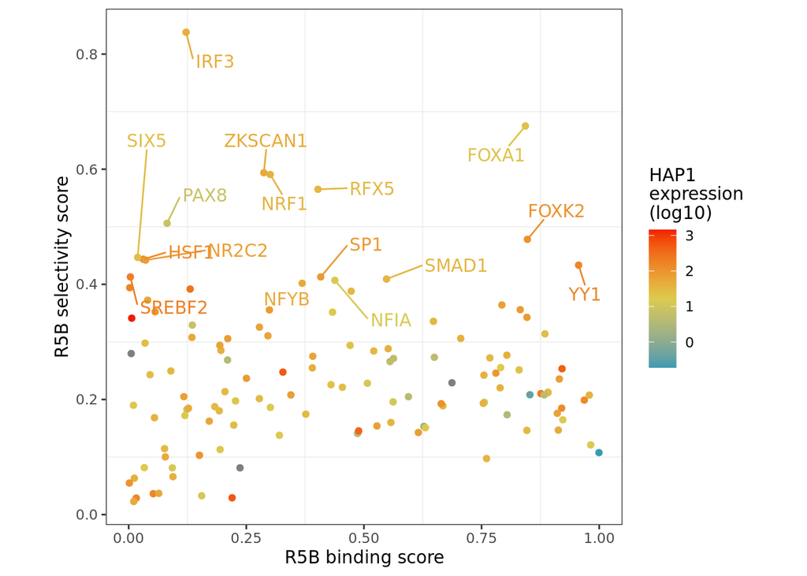

```r
# R

library(dplyr)
library(tidyr)
library(ggplot2)
library(ggrepel)
library(wesanderson)

# Load RNA-seq data
RNAseq.df <- read.table("/lustre/scratch126/gengen/projects/escramble/Dataset/RNAseq/gene_expression_table.tsv", header = T)

# Select maxatac TF
maxATAC.models.h5.df <- read.csv("/lustre/scratch126/gengen/projects/escramble/Data/maxatac/maxATAC.models.csv")
RNAseq.TF.df <- RNAseq.df %>% filter(gene %in% maxATAC.models.h5.df$TF) %>% mutate(HAP1 = (HAP1_c12_R1+HAP1_c12_R2)/2) %>% select(TF = gene, HAP1)

# Load maxatac data
R5B.enr.df <- readRDS("./001_Enhancer_mapping/rds/R5B.enr.df.rds")

# Add gene expression information
R5B.enr.exp.df <- R5B.enr.df %>% left_join(RNAseq.TF.df)

pal <- wes_palette("Zissou1", 3, type = "continuous")
R5B.TF.plot <- R5B.enr.exp.df %>%
  mutate(label = ifelse(R5B.enr >= 0.4, TF, "")) %>%
  ggplot(aes(x=R5B.score, y=R5B.enr, label=label, colour = log10(HAP1))) +
  geom_point() + geom_text_repel(aes(label = label), box.padding = 0.9) +
  scale_color_gradientn("HAP1\nexpression\n(log10)", colours = pal) +
  xlab("R5B binding score") + ylab("R5B selectivity score") +
  theme_bw() + theme(aspect.ratio=1, panel.grid.major = element_blank())
R5B.TF.plot
```

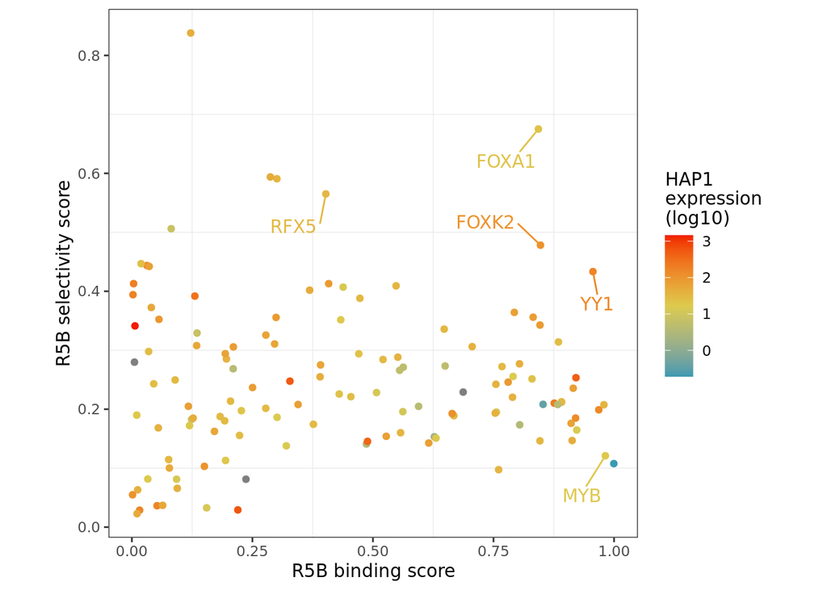

```r
R5B.TF.plot <- R5B.enr.exp.df %>%
  mutate(label = ifelse(TF %in% c("FOXA1", "FOXK2", "YY1", "RFX5", "MYB"), TF, "")) %>%
  ggplot(aes(x=R5B.score, y=R5B.enr, label=label, colour = log10(HAP1))) +
  geom_point() + geom_text_repel(aes(label = label), box.padding = 1) +
  scale_color_gradientn("HAP1\nexpression\n(log10)", colours = pal) +
  xlab("R5B binding score") + ylab("R5B selectivity score") +
  theme_bw() + theme(aspect.ratio=1, panel.grid.major = element_blank())
R5B.TF.plot
```

Interesting TFs include: - FOX family (FOXA1 and FOXK2) - YY1 - RFX5 - MYB

Indentify consensu binding motifs for targeting and mutagenesis

Position weight matrices (pwm) are recovered from the JASPAR database and processed with TFBSTools: - FOXA1: MA0148.5 - FOXK2: MA1103.3 - YY1: MA0095.2 - RFX5: MA0510.3 - MYB: MA0100.4

```r
library(TFBSTools)
library(Biostrings)
library(BSgenome.Hsapiens.UCSC.hg38)

setwd("/lustre/scratch126/gengen/projects/escramble")

# Load pfm

FOXA1.pfm <- readJASPARMatrix("/lustre/scratch126/gengen/projects/escramble/Dataset/JASPAR/MA0148.5.jaspar", matrixClass="PFM")
FOXK2.pfm <- readJASPARMatrix("/lustre/scratch126/gengen/projects/escramble/Dataset/JASPAR/MA1103.3.jaspar", matrixClass="PFM")
YY1.pfm <- readJASPARMatrix("/lustre/scratch126/gengen/projects/escramble/Dataset/JASPAR/MA0095.2.jaspar", matrixClass="PFM")
RFX5.pfm <- readJASPARMatrix("/lustre/scratch126/gengen/projects/escramble/Dataset/JASPAR/MA0510.3.jaspar", matrixClass="PFM")
MYB.pfm <- readJASPARMatrix("/lustre/scratch126/gengen/projects/escramble/Dataset/JASPAR/MA0100.4.jaspar", matrixClass="PFM")

# Plot seqlogo

seqLogo(toICM(FOXA1.pfm, pseudocounts=0.8, schneider=TRUE)$FOXA1)
seqLogo(toICM(FOXK2.pfm, pseudocounts=0.8, schneider=TRUE)$FOXK2)
seqLogo(toICM(YY1.pfm, pseudocounts=0.8, schneider=TRUE)$YY1)
seqLogo(toICM(RFX5.pfm, pseudocounts=0.8, schneider=TRUE)$RFX5)
seqLogo(toICM(MYB.pfm, pseudocounts=0.8, schneider=TRUE)$MYB)

# Recover sequence of R5B ATAC-seq peak
R5B.ATAC.peak.gr <- ATAC.peaks.gr[ATAC.peaks.gr$domain == "R5B"]

# We take a 500 bp domain centered on manually define peak
R5B.ATAC.peak.resize.gr <- resize(R5B.ATAC.peak.gr, 500, fix = "center")
R5B.ATAC.peak.seq <- getSeq(Hsapiens, R5B.ATAC.peak.resize.gr)

# Map consensus sequences

FOXA1.siteset <- searchSeq(toPWM(FOXA1.pfm, pseudocounts=0.8), R5B.ATAC.peak.seq, seqname="R5B", min.score="60%", strand="*")
FOXA1.siteset.df <- as.data.frame(writeGFF3(FOXA1.siteset))

FOXK2.siteset <- searchSeq(toPWM(FOXK2.pfm, pseudocounts=0.8), R5B.ATAC.peak.seq, seqname="R5B", min.score="60%", strand="*")
FOXK2.siteset.df <- as.data.frame(writeGFF3(FOXK2.siteset))

YY1.siteset <- searchSeq(toPWM(YY1.pfm, pseudocounts=0.8), R5B.ATAC.peak.seq, seqname="R5B", min.score="60%", strand="*")
YY1.siteset.df <- as.data.frame(writeGFF3(YY1.siteset))

RFX5.siteset <- searchSeq(toPWM(RFX5.pfm, pseudocounts=0.8), R5B.ATAC.peak.seq, seqname="R5B", min.score="60%", strand="*")
RFX5.siteset.df <- as.data.frame(writeGFF3(RFX5.siteset))

MYB.siteset <- searchSeq(toPWM(MYB.pfm, pseudocounts=0.8), R5B.ATAC.peak.seq, seqname="R5B", min.score="60%", strand="*")
MYB.siteset.df <- as.data.frame(writeGFF3(MYB.siteset))
```

A set of 12 epegRNAs were designed to target 6 FOXA1/FOXK2, 1 YY1, 1 RFX5 and 4 MYB binding site Oligonucleotide for cloning are designed locally ~/Desktop/Projects/EnhancerScramble/002_pegRNA_design_v1_4.Rmd

Prepare plots

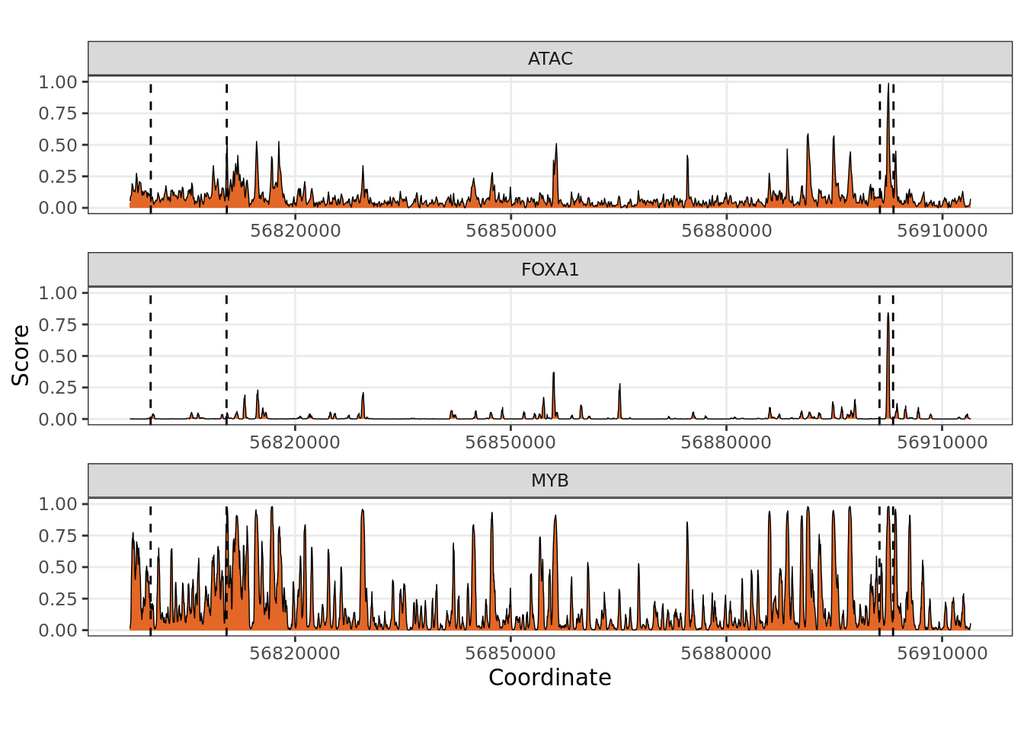

```r
library(rtracklayer)

# Load tracks
interval <- GRanges(seqnames = "chr14", ranges = IRanges(start = 56797000, end = 56914000))
ATAC.bw <- import("/lustre/scratch126/gengen/projects/escramble/Dataset/GSE108386/HAP1.ATAC.seq.bw", selection = interval)
FOXA1.bw <- import("/lustre/scratch126/gengen/projects/escramble/Data/maxatac/OTX2/HAP1_OTX2_FOXA1.bw", selection = interval)
RFX5.bw <- import("/lustre/scratch126/gengen/projects/escramble/Data/maxatac/OTX2/HAP1_OTX2_RFX5.bw", selection = interval)
MYB.bw <- import("/lustre/scratch126/gengen/projects/escramble/Data/maxatac/OTX2/HAP1_OTX2_MYB.bw", selection = interval)
YY1.bw <- import("/lustre/scratch126/gengen/projects/escramble/Data/maxatac/OTX2/HAP1_OTX2_YY1.bw", selection = interval)

# Prepare dataframes
ATAC.df <- as.data.frame(ATAC.bw) %>% mutate(track = "ATAC")
FOXA1.df <- as.data.frame(FOXA1.bw) %>% mutate(track = "FOXA1")
RFX5.df <- as.data.frame(RFX5.bw) %>% mutate(track = "RFX5")
MYB.df <- as.data.frame(MYB.bw) %>% mutate(track = "MYB")
YY1.df <- as.data.frame(YY1.bw) %>% mutate(track = "YY1")
maxATAC.df <- rbind(ATAC.df, MYB.df, FOXA1.df)

maxATAC.plot <- maxATAC.df %>% ggplot(aes(x = start, y = score)) +
  geom_area(col = NA, fill = "#E36726") +
  geom_line(size = 0.25) +
  ylab("Score") + xlab("Coordinate") + ylim(0,1) +
  geom_vline(xintercept=56799899, linetype="dashed") +
  geom_vline(xintercept=56810463, linetype="dashed") +
  geom_vline(xintercept=56901292, linetype="dashed") +
  geom_vline(xintercept=56903183, linetype="dashed") +
  facet_wrap(~ track, scales = "free", ncol = 1) +
  #scale_fill_manual(values=c(DEL.simple.OTX2.coverage.palette)) +
  theme_bw() + theme(aspect.ratio=0.15, panel.grid.minor = element_blank())
maxATAC.plot
```

```r
pdf("./Rplots/OTX2/OTX2.maxATAC.tracks.pdf", width=7, height=8, useDingbats=FALSE)
maxATAC.plot
dev.off()
```

# 2 File download

Sequencing data is recovered from Illumina basespace using command line

First run - 05/12/24 - sorted cells in triplicate, project: OTX super enhancer validation repeat - 439400999 (same project)

```bash
# bash
cd /lustre/scratch126/gengen/projects/escramble/Data/Illumina
mkdir 241205
cd 241205
# download data
bs download project -i 439400999 -o . --extension=fastq.gz
# 1st enrichment round
zcat ./12x_neg_1st_A_L001_ds.4d1a898965b5415e87bf05ec3e586d50/12x-neg-1st-A_S4_L001_R1_001.fastq.gz | wc -l | awk '{print $1/4}'
# 1,957,481 reads
zcat ./12x_neg_1st_B_L001_ds.ab131e4a230d434cbbec1d7a6eca0ec1/12x-neg-1st-B_S5_L001_R1_001.fastq.gz | wc -l | awk '{print $1/4}'
# 1,257,311 reads
zcat ./12x_neg_1st_C_L001_ds.b176d11730f54a7c915d3cf3253ee84b/12x-neg-1st-C_S6_L001_R1_001.fastq.gz | wc -l | awk '{print $1/4}'
# 2,548,558 reads
# 2nd enrichment round
# Count reads
zcat ./12x_neg_2nd_A_L001_ds.97066c49f0814507bba97fef73bb9f2e/12x-neg-2nd-A_S1_L001_R1_001.fastq.gz | wc -l | awk '{print $1/4}'
# 1,539,810 reads
zcat ./12x_neg_2nd_B_L001_ds.ceb1d85698c84031bff25014ddeef1f3/12x-neg-2nd-B_S2_L001_R1_001.fastq.gz | wc -l | awk '{print $1/4}'
# 1,822,182 reads
zcat ./12x_neg_2nd_C_L001_ds.c79cd70601934652b00d36cbb5422caf/12x-neg-2nd-C_S3_L001_R1_001.fastq.gz | wc -l | awk '{print $1/4}'
# 1,493,373 reads
# Total
# 10,618,715 total reads
```

Second run - 07/12/24 - unsorted cells in triplicate, project: OTX super enhancer validation repeat 2 - 439624060

```bash
# bash
cd /lustre/scratch126/gengen/projects/escramble/Data/Illumina
mkdir 241207
cd 241207
# download data
bs download project -i 439624060 -o . --extension=fastq.gz
# Count reads
zcat ./12xrep_A_L001_ds.93b04b1a47d3430cb38c53248d150b0b/12xrep-A_S1_L001_R1_001.fastq.gz | wc -l | awk '{print $1/4}'
# 1,782,314 reads
zcat ./12xrep_B_L001_ds.d0ef5a7156764f6f885bfefeaaa9cd75/12xrep-B_S2_L001_R1_001.fastq.gz | wc -l | awk '{print $1/4}'
# 3,464,326 reads
zcat ./12xrep_C_L001_ds.1ce46e492d064b6fb7a97930a9cee947/12xrep-C_S3_L001_R1_001.fastq.gz | wc -l | awk '{print $1/4}'
# 2,668,588 reads
# Total
# 7,915,228 total reads
```

# 3 Data formatting

The analysis pipeline consists in: - merge both R1 and R2 reads with PEAR - select amplicons with the right PCR primers (seqkit grep) - fwd: AGTCCCACCCTTAATCTCTTTGA, rev: TCATTCATGTTTGATTCAGCACA  
- grep patterns associated with the intended edits (seqkit grep)

This chunk report read merging

```bash
# bash
cd /lustre/scratch126/gengen/projects/escramble/Notebook/006_OTX2_TFBS_deletion_analysis/FASTQ

# Merge reads (with pear)

########

# Round 0 replicate A (1343620 reads)

bsub -q normal -n 12 -R'select[mem>32000] rusage[mem=32000] span[hosts=1]' -M32000 -o pear.log -J pear \
'conda_env="/software/hgi/envs/conda/team227/pm23/pear"
source /software/hgi/installs/conda-audited/miniconda/bin/activate $conda_env
pear -j 12 \
-f /lustre/scratch126/gengen/projects/escramble/Data/Illumina/241207/12xrep_A_L001_ds.93b04b1a47d3430cb38c53248d150b0b/12xrep-A_S1_L001_R1_001.fastq.gz \
-r /lustre/scratch126/gengen/projects/escramble/Data/Illumina/241207/12xrep_A_L001_ds.93b04b1a47d3430cb38c53248d150b0b/12xrep-A_S1_L001_R2_001.fastq.gz  \
-o OTX2_12TFBS_round0_repA
cat OTX2_12TFBS_round0_repA.assembled.fastq | wc -l | awk '{print $1/4}' > OTX2_12TFBS_round0_repA.read.count.txt'

# Round 0 replicate B (2964607 reads)

bsub -q normal -n 12 -R'select[mem>32000] rusage[mem=32000] span[hosts=1]' -M32000 -o pear.log -J pear \
'conda_env="/software/hgi/envs/conda/team227/pm23/pear"
source /software/hgi/installs/conda-audited/miniconda/bin/activate $conda_env
pear -j 12 \
-f /lustre/scratch126/gengen/projects/escramble/Data/Illumina/241207/12xrep_B_L001_ds.d0ef5a7156764f6f885bfefeaaa9cd75/12xrep-B_S2_L001_R1_001.fastq.gz \
-r /lustre/scratch126/gengen/projects/escramble/Data/Illumina/241207/12xrep_B_L001_ds.d0ef5a7156764f6f885bfefeaaa9cd75/12xrep-B_S2_L001_R2_001.fastq.gz  \
-o OTX2_12TFBS_round0_repB
cat OTX2_12TFBS_round0_repB.assembled.fastq | wc -l | awk '{print $1/4}' > OTX2_12TFBS_round0_repB.read.count.txt'

# Round 0 replicate C (2362566 reads)

bsub -q normal -n 12 -R'select[mem>32000] rusage[mem=32000] span[hosts=1]' -M32000 -o pear.log -J pear \
'conda_env="/software/hgi/envs/conda/team227/pm23/pear"
source /software/hgi/installs/conda-audited/miniconda/bin/activate $conda_env
pear -j 12 \
-f /lustre/scratch126/gengen/projects/escramble/Data/Illumina/241207/12xrep_C_L001_ds.1ce46e492d064b6fb7a97930a9cee947/12xrep-C_S3_L001_R1_001.fastq.gz \
-r /lustre/scratch126/gengen/projects/escramble/Data/Illumina/241207/12xrep_C_L001_ds.1ce46e492d064b6fb7a97930a9cee947/12xrep-C_S3_L001_R2_001.fastq.gz  \
-o OTX2_12TFBS_round0_repC
cat OTX2_12TFBS_round0_repC.assembled.fastq | wc -l | awk '{print $1/4}' > OTX2_12TFBS_round0_repC.read.count.txt'

########

# Round 1 replicate A (1739218 reads)

bsub -q normal -n 12 -R'select[mem>32000] rusage[mem=32000] span[hosts=1]' -M32000 -o pear.log -J pear \
'conda_env="/software/hgi/envs/conda/team227/pm23/pear"
source /software/hgi/installs/conda-audited/miniconda/bin/activate $conda_env
pear -j 12 \
-f /lustre/scratch126/gengen/projects/escramble/Data/Illumina/241205/12x_neg_1st_A_L001_ds.4d1a898965b5415e87bf05ec3e586d50/12x-neg-1st-A_S4_L001_R1_001.fastq.gz \
-r /lustre/scratch126/gengen/projects/escramble/Data/Illumina/241205/12x_neg_1st_A_L001_ds.4d1a898965b5415e87bf05ec3e586d50/12x-neg-1st-A_S4_L001_R2_001.fastq.gz  \
-o OTX2_12TFBS_round1_repA
cat OTX2_12TFBS_round1_repA.assembled.fastq | wc -l | awk '{print $1/4}' > OTX2_12TFBS_round1_repA.read.count.txt'

# Round 1 replicate B (1001061 reads)

bsub -q normal -n 12 -R'select[mem>32000] rusage[mem=32000] span[hosts=1]' -M32000 -o pear.log -J pear \
'conda_env="/software/hgi/envs/conda/team227/pm23/pear"
source /software/hgi/installs/conda-audited/miniconda/bin/activate $conda_env
pear -j 12 \
-f /lustre/scratch126/gengen/projects/escramble/Data/Illumina/241205/12x_neg_1st_B_L001_ds.ab131e4a230d434cbbec1d7a6eca0ec1/12x-neg-1st-B_S5_L001_R1_001.fastq.gz \
-r /lustre/scratch126/gengen/projects/escramble/Data/Illumina/241205/12x_neg_1st_B_L001_ds.ab131e4a230d434cbbec1d7a6eca0ec1/12x-neg-1st-B_S5_L001_R2_001.fastq.gz  \
-o OTX2_12TFBS_round1_repB
cat OTX2_12TFBS_round1_repB.assembled.fastq | wc -l | awk '{print $1/4}' > OTX2_12TFBS_round1_repB.read.count.txt'

# Round 1 replicate C (2176013 reads)

bsub -q normal -n 12 -R'select[mem>32000] rusage[mem=32000] span[hosts=1]' -M32000 -o pear.log -J pear \
'conda_env="/software/hgi/envs/conda/team227/pm23/pear"
source /software/hgi/installs/conda-audited/miniconda/bin/activate $conda_env
pear -j 12 \
-f /lustre/scratch126/gengen/projects/escramble/Data/Illumina/241205/12x_neg_1st_C_L001_ds.b176d11730f54a7c915d3cf3253ee84b/12x-neg-1st-C_S6_L001_R1_001.fastq.gz \
-r /lustre/scratch126/gengen/projects/escramble/Data/Illumina/241205/12x_neg_1st_C_L001_ds.b176d11730f54a7c915d3cf3253ee84b/12x-neg-1st-C_S6_L001_R2_001.fastq.gz  \
-o OTX2_12TFBS_round1_repC
cat OTX2_12TFBS_round1_repC.assembled.fastq | wc -l | awk '{print $1/4}' > OTX2_12TFBS_round1_repC.read.count.txt'

########

# Round 2 replicate A (1247791 reads)

bsub -q normal -n 12 -R'select[mem>32000] rusage[mem=32000] span[hosts=1]' -M32000 -o pear.log -J pear \
'conda_env="/software/hgi/envs/conda/team227/pm23/pear"
source /software/hgi/installs/conda-audited/miniconda/bin/activate $conda_env
pear -j 12 \
-f /lustre/scratch126/gengen/projects/escramble/Data/Illumina/241205/12x_neg_2nd_A_L001_ds.97066c49f0814507bba97fef73bb9f2e/12x-neg-2nd-A_S1_L001_R1_001.fastq.gz \
-r /lustre/scratch126/gengen/projects/escramble/Data/Illumina/241205/12x_neg_2nd_A_L001_ds.97066c49f0814507bba97fef73bb9f2e/12x-neg-2nd-A_S1_L001_R2_001.fastq.gz  \
-o OTX2_12TFBS_round2_repA
cat OTX2_12TFBS_round2_repA.assembled.fastq | wc -l | awk '{print $1/4}' > OTX2_12TFBS_round2_repA.read.count.txt'

# Round 2 replicate B (1157701 reads)

bsub -q normal -n 12 -R'select[mem>32000] rusage[mem=32000] span[hosts=1]' -M32000 -o pear.log -J pear \
'conda_env="/software/hgi/envs/conda/team227/pm23/pear"
source /software/hgi/installs/conda-audited/miniconda/bin/activate $conda_env
pear -j 12 \
-f /lustre/scratch126/gengen/projects/escramble/Data/Illumina/241205/12x_neg_2nd_B_L001_ds.ceb1d85698c84031bff25014ddeef1f3/12x-neg-2nd-B_S2_L001_R1_001.fastq.gz \
-r /lustre/scratch126/gengen/projects/escramble/Data/Illumina/241205/12x_neg_2nd_B_L001_ds.ceb1d85698c84031bff25014ddeef1f3/12x-neg-2nd-B_S2_L001_R2_001.fastq.gz  \
-o OTX2_12TFBS_round2_repB
cat OTX2_12TFBS_round2_repB.assembled.fastq | wc -l | awk '{print $1/4}' > OTX2_12TFBS_round2_repB.read.count.txt'

# Round 2 replicate C (1153022 reads)

bsub -q normal -n 12 -R'select[mem>32000] rusage[mem=32000] span[hosts=1]' -M32000 -o pear.log -J pear \
'conda_env="/software/hgi/envs/conda/team227/pm23/pear"
source /software/hgi/installs/conda-audited/miniconda/bin/activate $conda_env
pear -j 12 \
-f /lustre/scratch126/gengen/projects/escramble/Data/Illumina/241205/12x_neg_2nd_C_L001_ds.c79cd70601934652b00d36cbb5422caf/12x-neg-2nd-C_S3_L001_R1_001.fastq.gz \
-r /lustre/scratch126/gengen/projects/escramble/Data/Illumina/241205/12x_neg_2nd_C_L001_ds.c79cd70601934652b00d36cbb5422caf/12x-neg-2nd-C_S3_L001_R2_001.fastq.gz  \
-o OTX2_12TFBS_round2_repC
cat OTX2_12TFBS_round2_repC.assembled.fastq | wc -l | awk '{print $1/4}' > OTX2_12TFBS_round2_repC.read.count.txt'
```

Select amplicons from reads that have both fwd and rev primers

```bash
cd /lustre/scratch126/gengen/projects/escramble/Notebook/006_OTX2_TFBS_deletion_analysis/FASTQ

# Select amplicons that have both fwd and rev primers

# Sample to be analysed

# OTX2_12TFBS_round0_repA
# OTX2_12TFBS_round0_repB
# OTX2_12TFBS_round0_repC
# OTX2_12TFBS_round1_repA
# OTX2_12TFBS_round1_repB
# OTX2_12TFBS_round1_repC
# OTX2_12TFBS_round2_repA
# OTX2_12TFBS_round2_repB
# OTX2_12TFBS_round2_repC

bsub -q normal -n 16 -R'select[mem>32000] rusage[mem=32000]' -M 32000 -o pattern.log \
'

# Define sample name and create working directory
cd /lustre/scratch126/gengen/projects/escramble/Notebook/006_OTX2_TFBS_deletion_analysis/FASTQ
SAMPLE_NAME="OTX2_12TFBS_round2_repC"
mkdir ${SAMPLE_NAME}

# Load seqkit conda environment
conda_env="/software/hgi/envs/conda/team227/pm23/seqkit"
source /software/hgi/installs/conda-audited/miniconda/bin/activate $conda_env

# Select amplicons that have both fwd and rev primer
seqkit amplicon -I --max-mismatch 4 -j 8 -F "AGTCCCACCCTTAATCTCTTTGA" -R "TCATTCATGTTTGATTCAGCACA" ${SAMPLE_NAME}.assembled.fastq \
> ${SAMPLE_NAME}.amplicon.fastq
'
```

# 4 Crispresso2 (all deletions)

Edits quantification is assessed using CRISPResso2 (https://github.com/pinellolab/CRISPResso2)

CRISPResso is run for each experiment providing the position of the expected edits Position of the TFBSs in the amplicon: - FOXA1_1: pos 58-65 - FOXA1_2: pos 152-159 - FOXA1_3: pos 219-226 - FOXA1_4: pos 249-256 - FOXA1_5: pos 270-277 - FOXA1_6: pos 374-381 - RFX5: pos 35-48 - YY1: pos 355-365 - MYB_1: pos 201-206 - MYB_2: pos 278-283 - MYB_3: pos 325-330 - MYB_4: pos 366-371

Edit quantification is performed by assessing the number of reads that support a deletion over the TFBS of interest

```bash
# bash

# Round 0 replicate A

bsub -q normal -n 12 -R'select[mem>32000] rusage[mem=32000] span[hosts=1]' -M32000 -o CRISPResso.log -J CRISPResso \
'cd /lustre/scratch126/gengen/projects/escramble/Notebook/006_OTX2_TFBS_deletion_analysis/CRISPRessoQWC
AMPLICON_seq="AGTCCCACCCTTAATCTCTTTGAGGCCTCTATGAGTTTCCATAGCACTTTACAAAAGATC…"
conda_env="/software/hgi/envs/conda/team227/pm23/crispresso2"
source /software/hgi/installs/conda-audited/miniconda/bin/activate $conda_env
CRISPResso \
--fastq_r1 /lustre/scratch126/gengen/projects/escramble/Notebook/006_OTX2_TFBS_deletion_analysis/FASTQ/OTX2_12TFBS_round0_repA.amplicon.fastq \
--quantification_window_coordinates 35-48_58-65_152-159_201-206_219-226_249-256_270-277_278-283_325-330_355-365_366-371_374-381 \
--amplicon_seq $AMPLICON_seq --name R0_repA'

# Round 0 replicate B

bsub -q normal -n 12 -R'select[mem>32000] rusage[mem=32000] span[hosts=1]' -M32000 -o CRISPResso.log -J CRISPResso \
'cd /lustre/scratch126/gengen/projects/escramble/Notebook/006_OTX2_TFBS_deletion_analysis/CRISPRessoQWC
AMPLICON_seq="AGTCCCACCCTTAATCTCTTTGAGGCCTCTATGAGTTTCCATAGCACTTTACAAAAGATC…"
conda_env="/software/hgi/envs/conda/team227/pm23/crispresso2"
source /software/hgi/installs/conda-audited/miniconda/bin/activate $conda_env
CRISPResso \
--fastq_r1 /lustre/scratch126/gengen/projects/escramble/Notebook/006_OTX2_TFBS_deletion_analysis/FASTQ/OTX2_12TFBS_round0_repB.amplicon.fastq \
--quantification_window_coordinates 35-48_58-65_152-159_201-206_219-226_249-256_270-277_278-283_325-330_355-365_366-371_374-381 \
--amplicon_seq $AMPLICON_seq --name R0_repB'

# Round 0 replicate C

bsub -q normal -n 12 -R'select[mem>32000] rusage[mem=32000] span[hosts=1]' -M32000 -o CRISPResso.log -J CRISPResso \
'cd /lustre/scratch126/gengen/projects/escramble/Notebook/006_OTX2_TFBS_deletion_analysis/CRISPRessoQWC
AMPLICON_seq="AGTCCCACCCTTAATCTCTTTGAGGCCTCTATGAGTTTCCATAGCACTTTACAAAAGATC…"
conda_env="/software/hgi/envs/conda/team227/pm23/crispresso2"
source /software/hgi/installs/conda-audited/miniconda/bin/activate $conda_env
CRISPResso \
--fastq_r1 /lustre/scratch126/gengen/projects/escramble/Notebook/006_OTX2_TFBS_deletion_analysis/FASTQ/OTX2_12TFBS_round0_repC.amplicon.fastq \
--quantification_window_coordinates 35-48_58-65_152-159_201-206_219-226_249-256_270-277_278-283_325-330_355-365_366-371_374-381 \
--amplicon_seq $AMPLICON_seq --name R0_repC'

# Round 1 replicate A

bsub -q normal -n 12 -R'select[mem>32000] rusage[mem=32000] span[hosts=1]' -M32000 -o CRISPResso.log -J CRISPResso \
'cd /lustre/scratch126/gengen/projects/escramble/Notebook/006_OTX2_TFBS_deletion_analysis/CRISPRessoQWC
AMPLICON_seq="AGTCCCACCCTTAATCTCTTTGAGGCCTCTATGAGTTTCCATAGCACTTTACAAAAGATC…"
conda_env="/software/hgi/envs/conda/team227/pm23/crispresso2"
source /software/hgi/installs/conda-audited/miniconda/bin/activate $conda_env
CRISPResso \
--fastq_r1 /lustre/scratch126/gengen/projects/escramble/Notebook/006_OTX2_TFBS_deletion_analysis/FASTQ/OTX2_12TFBS_round1_repA.amplicon.fastq \
--quantification_window_coordinates 35-48_58-65_152-159_201-206_219-226_249-256_270-277_278-283_325-330_355-365_366-371_374-381 \
--amplicon_seq $AMPLICON_seq --name R1_repA'

# Round 1 replicate B

bsub -q normal -n 12 -R'select[mem>32000] rusage[mem=32000] span[hosts=1]' -M32000 -o CRISPResso.log -J CRISPResso \
'cd /lustre/scratch126/gengen/projects/escramble/Notebook/006_OTX2_TFBS_deletion_analysis/CRISPRessoQWC
AMPLICON_seq="AGTCCCACCCTTAATCTCTTTGAGGCCTCTATGAGTTTCCATAGCACTTTACAAAAGATC…"
conda_env="/software/hgi/envs/conda/team227/pm23/crispresso2"
source /software/hgi/installs/conda-audited/miniconda/bin/activate $conda_env
CRISPResso \
--fastq_r1 /lustre/scratch126/gengen/projects/escramble/Notebook/006_OTX2_TFBS_deletion_analysis/FASTQ/OTX2_12TFBS_round1_repB.amplicon.fastq \
--quantification_window_coordinates 35-48_58-65_152-159_201-206_219-226_249-256_270-277_278-283_325-330_355-365_366-371_374-381 \
--amplicon_seq $AMPLICON_seq --name R1_repB'

# Round 1 replicate C

bsub -q normal -n 12 -R'select[mem>32000] rusage[mem=32000] span[hosts=1]' -M32000 -o CRISPResso.log -J CRISPResso \
'cd /lustre/scratch126/gengen/projects/escramble/Notebook/006_OTX2_TFBS_deletion_analysis/CRISPRessoQWC
AMPLICON_seq="AGTCCCACCCTTAATCTCTTTGAGGCCTCTATGAGTTTCCATAGCACTTTACAAAAGATC…"
conda_env="/software/hgi/envs/conda/team227/pm23/crispresso2"
source /software/hgi/installs/conda-audited/miniconda/bin/activate $conda_env
CRISPResso \
--fastq_r1 /lustre/scratch126/gengen/projects/escramble/Notebook/006_OTX2_TFBS_deletion_analysis/FASTQ/OTX2_12TFBS_round1_repC.amplicon.fastq \
--quantification_window_coordinates 35-48_58-65_152-159_201-206_219-226_249-256_270-277_278-283_325-330_355-365_366-371_374-381 \
--amplicon_seq $AMPLICON_seq --name R1_repC'

# Round 2 replicate A

bsub -q normal -n 12 -R'select[mem>32000] rusage[mem=32000] span[hosts=1]' -M32000 -o CRISPResso.log -J CRISPResso \
'cd /lustre/scratch126/gengen/projects/escramble/Notebook/006_OTX2_TFBS_deletion_analysis/CRISPRessoQWC
AMPLICON_seq="AGTCCCACCCTTAATCTCTTTGAGGCCTCTATGAGTTTCCATAGCACTTTACAAAAGATC…"
conda_env="/software/hgi/envs/conda/team227/pm23/crispresso2"
source /software/hgi/installs/conda-audited/miniconda/bin/activate $conda_env
CRISPResso \
--fastq_r1 /lustre/scratch126/gengen/projects/escramble/Notebook/006_OTX2_TFBS_deletion_analysis/FASTQ/OTX2_12TFBS_round2_repA.amplicon.fastq \
--quantification_window_coordinates 35-48_58-65_152-159_201-206_219-226_249-256_270-277_278-283_325-330_355-365_366-371_374-381 \
--amplicon_seq $AMPLICON_seq --name R2_repA'

# Round 2 replicate B

bsub -q normal -n 12 -R'select[mem>32000] rusage[mem=32000] span[hosts=1]' -M32000 -o CRISPResso.log -J CRISPResso \
'cd /lustre/scratch126/gengen/projects/escramble/Notebook/006_OTX2_TFBS_deletion_analysis/CRISPRessoQWC
AMPLICON_seq="AGTCCCACCCTTAATCTCTTTGAGGCCTCTATGAGTTTCCATAGCACTTTACAAAAGATC…"
conda_env="/software/hgi/envs/conda/team227/pm23/crispresso2"
source /software/hgi/installs/conda-audited/miniconda/bin/activate $conda_env
CRISPResso \
--fastq_r1 /lustre/scratch126/gengen/projects/escramble/Notebook/006_OTX2_TFBS_deletion_analysis/FASTQ/OTX2_12TFBS_round2_repB.amplicon.fastq \
--quantification_window_coordinates 35-48_58-65_152-159_201-206_219-226_249-256_270-277_278-283_325-330_355-365_366-371_374-381 \
--amplicon_seq $AMPLICON_seq --name R2_repB'

# Round 2 replicate C

bsub -q normal -n 12 -R'select[mem>32000] rusage[mem=32000] span[hosts=1]' -M32000 -o CRISPResso.log -J CRISPResso \
'cd /lustre/scratch126/gengen/projects/escramble/Notebook/006_OTX2_TFBS_deletion_analysis/CRISPRessoQWC
AMPLICON_seq="AGTCCCACCCTTAATCTCTTTGAGGCCTCTATGAGTTTCCATAGCACTTTACAAAAGATC…"
conda_env="/software/hgi/envs/conda/team227/pm23/crispresso2"
source /software/hgi/installs/conda-audited/miniconda/bin/activate $conda_env
CRISPResso \
--fastq_r1 /lustre/scratch126/gengen/projects/escramble/Notebook/006_OTX2_TFBS_deletion_analysis/FASTQ/OTX2_12TFBS_round2_repC.amplicon.fastq \
--quantification_window_coordinates 35-48_58-65_152-159_201-206_219-226_249-256_270-277_278-283_325-330_355-365_366-371_374-381 \
--amplicon_seq $AMPLICON_seq --name R2_repC'
```

Analyse results

```r
# R

#######################
# Load CRISPResso results

R0.repA.mod.count.df <- read.table("/lustre/scratch126/gengen/projects/escramble/Notebook/006_OTX2_TFBS_deletion_analysis/CRISPRessoQWC/CRISPResso_on_R0_repA/Quantification_window_modification_count_vectors.txt", row.names = 1)

R0.repB.mod.count.df <- read.table("/lustre/scratch126/gengen/projects/escramble/Notebook/006_OTX2_TFBS_deletion_analysis/CRISPRessoQWC/CRISPResso_on_R0_repB/Quantification_window_modification_count_vectors.txt", row.names = 1)

R0.repC.mod.count.df <- read.table("/lustre/scratch126/gengen/projects/escramble/Notebook/006_OTX2_TFBS_deletion_analysis/CRISPRessoQWC/CRISPResso_on_R0_repC/Quantification_window_modification_count_vectors.txt", row.names = 1)

R1.repA.mod.count.df <- read.table("/lustre/scratch126/gengen/projects/escramble/Notebook/006_OTX2_TFBS_deletion_analysis/CRISPRessoQWC/CRISPResso_on_R1_repA/Quantification_window_modification_count_vectors.txt", row.names = 1)

R1.repB.mod.count.df <- read.table("/lustre/scratch126/gengen/projects/escramble/Notebook/006_OTX2_TFBS_deletion_analysis/CRISPRessoQWC/CRISPResso_on_R1_repB/Quantification_window_modification_count_vectors.txt", row.names = 1)

R1.repC.mod.count.df <- read.table("/lustre/scratch126/gengen/projects/escramble/Notebook/006_OTX2_TFBS_deletion_analysis/CRISPRessoQWC/CRISPResso_on_R1_repC/Quantification_window_modification_count_vectors.txt", row.names = 1)

R2.repA.mod.count.df <- read.table("/lustre/scratch126/gengen/projects/escramble/Notebook/006_OTX2_TFBS_deletion_analysis/CRISPRessoQWC/CRISPResso_on_R2_repA/Quantification_window_modification_count_vectors.txt", row.names = 1)

R2.repB.mod.count.df <- read.table("/lustre/scratch126/gengen/projects/escramble/Notebook/006_OTX2_TFBS_deletion_analysis/CRISPRessoQWC/CRISPResso_on_R2_repB/Quantification_window_modification_count_vectors.txt", row.names = 1)

R2.repC.mod.count.df <- read.table("/lustre/scratch126/gengen/projects/escramble/Notebook/006_OTX2_TFBS_deletion_analysis/CRISPRessoQWC/CRISPResso_on_R2_repC/Quantification_window_modification_count_vectors.txt", row.names = 1)

#####################
# Define functions

# Function to extract deletion frequency over the amplicons

DEL.freq.amplicon.fun <- function(deletion.coverage) { # Result from CRISPResso analysis Quantification_window_modification_count_vectors.txt
  # add position information
  position <- seq_along(deletion.coverage)
  deletion.coverage <- rbind(position, deletion.coverage)
  rownames(deletion.coverage) <- c("pos", "sequence", "insertions", "deletions", "substitutions", "all_modifications", "read.count")
  # reformat
  deletion.coverage <- t(deletion.coverage) %>% as.data.frame() %>% mutate(across(-sequence, as.numeric))
  # compute insertion frequencies in percentage
  deletion.coverage <- deletion.coverage %>% mutate(del.freq = (deletions/read.count)*100)
  return(deletion.coverage)
}

# Function to extract deletion frequency at TFBS

DEL.freq.TFBS.fun <- function(deletion.coverage, sample) { # deletion.coverages the ouput of DEL.freq.amplicon.fun, sample the sample name
  # Pull individual values at TFBS
  FOXA1_1.val <- deletion.coverage %>% filter(pos >= 58 & pos <= 65) %>% pull(del.freq) %>% mean()
  FOXA1_2.val <- deletion.coverage %>% filter(pos >= 152 & pos <= 159) %>% pull(del.freq) %>% mean()
  FOXA1_3.val <- deletion.coverage %>% filter(pos >= 219 & pos <= 226) %>% pull(del.freq) %>% mean()
  FOXA1_4.val <- deletion.coverage %>% filter(pos >= 249 & pos <= 256) %>% pull(del.freq) %>% mean()
  FOXA1_5.val <- deletion.coverage %>% filter(pos >= 270 & pos <= 277) %>% pull(del.freq) %>% mean()
  FOXA1_6.val <- deletion.coverage %>% filter(pos >= 374 & pos <= 381) %>% pull(del.freq) %>% mean()
  RFX5.val <- deletion.coverage %>% filter(pos >= 35 & pos <= 48) %>% pull(del.freq) %>% mean()
  YY1.val <- deletion.coverage %>% filter(pos >= 355 & pos <= 365) %>% pull(del.freq) %>% mean()
  MYB_1.val <- deletion.coverage %>% filter(pos >= 201 & pos <= 206) %>% pull(del.freq) %>% mean()
  MYB_2.val <- deletion.coverage %>% filter(pos >= 278 & pos <= 283) %>% pull(del.freq) %>% mean()
  MYB_3.val <- deletion.coverage %>% filter(pos >= 325 & pos <= 330) %>% pull(del.freq) %>% mean()
  MYB_4.val <- deletion.coverage %>% filter(pos >= 366 & pos <= 371) %>% pull(del.freq) %>% mean()
  # Prepare summaru table
  del.TFBS.freq.df <- tibble(sample = rep(sample, 12),
                             TFBS = c("FOXA1_1", "FOXA1_2", "FOXA1_3", "FOXA1_4", "FOXA1_5", "FOXA1_6", "RFX5", "YY1", "MYB_1", "MYB_2", "MYB_3", "MYB_4"),
                             del.freq = c(FOXA1_1.val, FOXA1_2.val, FOXA1_3.val, FOXA1_4.val, FOXA1_5.val, FOXA1_6.val, RFX5.val, YY1.val, MYB_1.val, MYB_2.val, MYB_3.val, MYB_4.val))
}

#####################
# Compute frequencies

R0.repA.del.count.df <- DEL.freq.amplicon.fun(R0.repA.mod.count.df)
R0.repA.TFBS.del.freq.df <- DEL.freq.TFBS.fun(R0.repA.del.count.df, "R0.repA")

R0.repB.del.count.df <- DEL.freq.amplicon.fun(R0.repB.mod.count.df)
R0.repB.TFBS.del.freq.df <- DEL.freq.TFBS.fun(R0.repB.del.count.df, "R0.repB")

R0.repC.del.count.df <- DEL.freq.amplicon.fun(R0.repC.mod.count.df)
R0.repC.TFBS.del.freq.df <- DEL.freq.TFBS.fun(R0.repC.del.count.df, "R0.repC")

R1.repA.del.count.df <- DEL.freq.amplicon.fun(R1.repA.mod.count.df)
R1.repA.TFBS.del.freq.df <- DEL.freq.TFBS.fun(R1.repA.del.count.df, "R1.repA")

R1.repB.del.count.df <- DEL.freq.amplicon.fun(R1.repB.mod.count.df)
R1.repB.TFBS.del.freq.df <- DEL.freq.TFBS.fun(R1.repB.del.count.df, "R1.repB")

R1.repC.del.count.df <- DEL.freq.amplicon.fun(R1.repC.mod.count.df)
R1.repC.TFBS.del.freq.df <- DEL.freq.TFBS.fun(R1.repC.del.count.df, "R1.repC")

R2.repA.del.count.df <- DEL.freq.amplicon.fun(R2.repA.mod.count.df)
R2.repA.TFBS.del.freq.df <- DEL.freq.TFBS.fun(R2.repA.del.count.df, "R2.repA")

R2.repB.del.count.df <- DEL.freq.amplicon.fun(R2.repB.mod.count.df)
R2.repB.TFBS.del.freq.df <- DEL.freq.TFBS.fun(R2.repB.del.count.df, "R2.repB")

R2.repC.del.count.df <- DEL.freq.amplicon.fun(R2.repC.mod.count.df)
R2.repC.TFBS.del.freq.df <- DEL.freq.TFBS.fun(R2.repC.del.count.df, "R2.repC")

#####################
# Combine information

# Deletion coverage

R0.repA.del.count.reform.df <- R0.repA.del.count.df %>% dplyr::select(pos, R0.repA.del.freq = del.freq)
R0.repB.del.count.reform.df <- R0.repB.del.count.df %>% dplyr::select(pos, R0.repB.del.freq = del.freq)
R0.repC.del.count.reform.df <- R0.repC.del.count.df %>% dplyr::select(pos, R0.repC.del.freq = del.freq)
R0.del.count.reform.df <- R0.repA.del.count.reform.df %>% left_join(R0.repB.del.count.reform.df) %>% left_join(R0.repC.del.count.reform.df) %>%
  mutate(del.freq = (R0.repA.del.freq+R0.repB.del.freq+R0.repC.del.freq)/3) %>% dplyr::select(pos, del.freq) %>% mutate(round = 0)
R1.repA.del.count.reform.df <- R1.repA.del.count.df %>% dplyr::select(pos, R1.repA.del.freq = del.freq)
R1.repB.del.count.reform.df <- R1.repB.del.count.df %>% dplyr::select(pos, R1.repB.del.freq = del.freq)
R1.repC.del.count.reform.df <- R1.repC.del.count.df %>% dplyr::select(pos, R1.repC.del.freq = del.freq)
R1.del.count.reform.df <- R1.repA.del.count.reform.df %>% left_join(R1.repB.del.count.reform.df) %>% left_join(R1.repC.del.count.reform.df) %>%
  mutate(del.freq = (R1.repA.del.freq+R1.repB.del.freq+R1.repC.del.freq)/3) %>% dplyr::select(pos, del.freq) %>% mutate(round = 1)
R2.repA.del.count.reform.df <- R2.repA.del.count.df %>% dplyr::select(pos, R2.repA.del.freq = del.freq)
R2.repB.del.count.reform.df <- R2.repB.del.count.df %>% dplyr::select(pos, R2.repB.del.freq = del.freq)
R2.repC.del.count.reform.df <- R2.repC.del.count.df %>% dplyr::select(pos, R2.repC.del.freq = del.freq)
R2.del.count.reform.df <- R2.repA.del.count.reform.df %>% left_join(R2.repB.del.count.reform.df) %>% left_join(R2.repC.del.count.reform.df) %>%
  mutate(del.freq = (R2.repA.del.freq+R2.repB.del.freq+R2.repC.del.freq)/3) %>% dplyr::select(pos, del.freq) %>% mutate(round = 2)
del.count.amplicon.summary.df <- rbind(R0.del.count.reform.df, R1.del.count.reform.df, R2.del.count.reform.df)
saveRDS(del.count.amplicon.summary.df, "./006_OTX2_TFBS_deletion_analysis/rds/del.count.amplicon.summary.df.rds")

# Deletion frequency at TFBS

TFBS.del.freq.summary.df <- rbind(R0.repA.TFBS.del.freq.df, R0.repB.TFBS.del.freq.df, R0.repC.TFBS.del.freq.df,
                                  R1.repA.TFBS.del.freq.df, R1.repB.TFBS.del.freq.df, R1.repC.TFBS.del.freq.df,
                                  R2.repA.TFBS.del.freq.df, R2.repB.TFBS.del.freq.df, R2.repC.TFBS.del.freq.df) %>%
                            tidyr::separate(sample, c("round", "rep"), sep = "\\.") %>%
                            mutate(round = gsub("R", "", round)) %>%
                            mutate(rep = gsub("rep", "", rep))

# Pull values observed before sorting
del.freq.ref.df <- TFBS.del.freq.summary.df %>% group_by(TFBS, round) %>% summarise(del.freq.ref = mean(del.freq, na.rm = T)) %>% filter(round == 0) %>% dplyr::select(-round) %>% ungroup()

# Compute enrichment
TFBS.del.freq.summary.df <- TFBS.del.freq.summary.df %>%
  left_join(del.freq.ref.df, by = "TFBS") %>%
  mutate(del.enr = del.freq/del.freq.ref)
saveRDS(TFBS.del.freq.summary.df, "./006_OTX2_TFBS_deletion_analysis/rds/TFBS.del.freq.summary.df.rds")
```

Plot

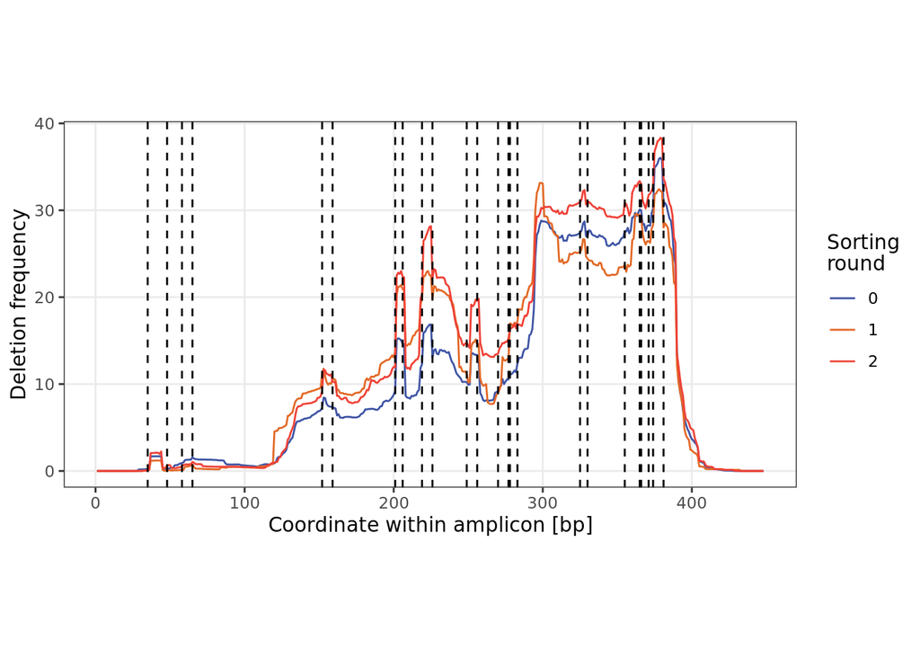

```r
library(dplyr)
library(tidyr)
library(ggplot2)
library(forcats)
library(ggpubr)

# Load data
del.count.amplicon.summary.df <- readRDS("./006_OTX2_TFBS_deletion_analysis/rds/del.count.amplicon.summary.df.rds")
TFBS.del.freq.summary.df <- readRDS("./006_OTX2_TFBS_deletion_analysis/rds/TFBS.del.freq.summary.df.rds")

# Plot the frequency of deletion over the amplicon

vline <- c(58, 65, 152, 159, 219, 226, 249, 256, 270, 277, 374, 381, 35, 48, 355, 365, 201, 206, 278, 283, 325, 330, 366, 371)
del.count.amplicon.summary.plot <- del.count.amplicon.summary.df %>% ggplot(aes(x=pos, y=del.freq, colour = as.character(round))) +
  geom_line() +
  theme_bw() + xlab("Coordinate within amplicon [bp]") + ylab("Deletion frequency") +
  geom_vline(xintercept=vline, linetype="dashed") +
  scale_color_manual("Sorting\nround", values = c("#3E54A4", "#E36826", "#EF4136")) +
  theme(aspect.ratio = 0.5, panel.grid.minor = element_blank())
del.count.amplicon.summary.plot
```

```r
pdf("./Rplots/OTX2/TFBS.deletion.freq.pdf", width=7, height=3, useDingbats=FALSE)
del.count.amplicon.summary.plot
dev.off()
```

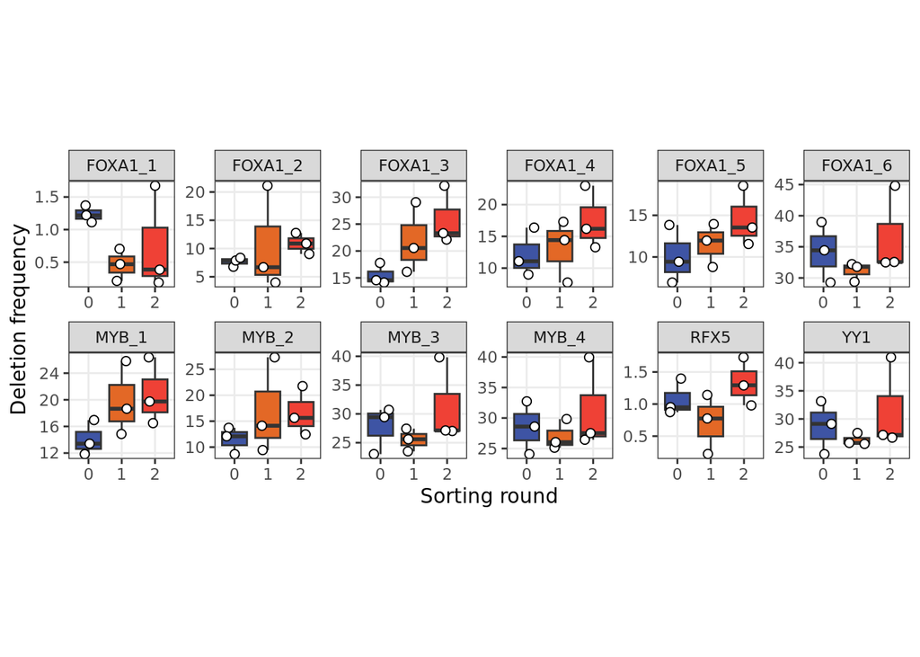

```r
# Plot the frequency of deletion over TFBSs

del.freq.TFBS.plot <- TFBS.del.freq.summary.df %>%
  ggplot(aes(x = round, y = del.freq, fill = round)) +
  geom_boxplot() +
  geom_jitter(width = 0.25, size = 2, shape = 21, fill = "white") +
  xlab("Sorting round") + ylab("Deletion frequency") +
  scale_fill_manual("Sorting\nround", values = c("#3E54A4", "#E36826", "#EF4136")) +
  facet_wrap(~ TFBS, scales = "free", ncol = 6) +
  theme_bw() + theme(aspect.ratio=1, panel.grid.minor = element_blank(), legend.position="none")
del.freq.TFBS.plot
```

```r
pdf("./Rplots/OTX2/TFBS.deletion.at.TFBS.freq.pdf", width=10, height=4, useDingbats=FALSE)
del.freq.TFBS.plot
dev.off()
```

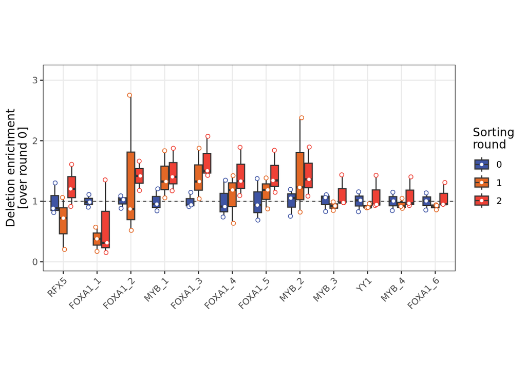

```r
# Plot deletion enrichment over TFBSs

TFBS.del.freq.summary.plot <- TFBS.del.freq.summary.df %>%
  mutate(tfbs = fct_relevel(TFBS, "RFX5", "FOXA1_1", "FOXA1_2", "MYB_1", "FOXA1_3", "FOXA1_4", "FOXA1_5", "MYB_2", "MYB_3", "YY1", "MYB_4", "FOXA1_6")) %>%
  ggplot(aes(x = tfbs, y = del.enr, fill = round)) +
  geom_hline(yintercept=1, linetype="dashed", linewidth = 0.25) +
  geom_boxplot() +
  geom_jitter(position = position_jitterdodge(dodge.width = 0.75, jitter.width = 0.1), aes(color = round), shape = 21, fill = "white") + ylim(0,3.1) +
  scale_color_manual("Sorting\nround", values = c("#3E54A4", "#E36826", "#EF4136")) +
  scale_fill_manual("Sorting\nround", values = c("#3E54A4", "#E36826", "#EF4136")) +
  ylab("Deletion enrichment\n[over round 0]") +
  theme_bw() +
  theme(aspect.ratio = 0.5, panel.grid.minor = element_blank(), axis.title.x = element_blank(),, axis.text.x = element_text(angle = 45, hjust = 1))
TFBS.del.freq.summary.plot
```

```r
pdf("./Rplots/OTX2/TFBS.deletion.at.TFBS.enrichment.pdf", width=7, height=4, useDingbats=FALSE)
TFBS.del.freq.summary.plot
dev.off()
```

```r
# Compute p-values (t-test)

# RFX5,  p-value = 0.1977
# FOXA1_1, p-value = 0.797
# FOXA1_2, p-value = 0.03924 (*)
# MYB_1,  p-value = 0.04462 (*)
# FOXA1_3, p-value = 0.03396 (*)
# FOXA1_4, p-value = 0.04943 (*)
# FOXA1_5, p-value = 0.09864
# MYB_2, p-value = 0.04731 (*)
# MYB_3, p-value = 0.2549
# YY1, p-value = 0.3124
# MYB_4, p-value = 0.3042
# FOXA1_6, p-value = 0.3285
```

# 5 Crispresso2 (PE mode)

Use Crispresso2 in Prime Editing mode to characterise the deletions at targeted TFBSs

Generate a lookup table reporting TFBS, sample name, FASTQ path, spacer and pegRNA extension sequences.

Spacer and pegRNA extension sequences need to be reported at the RNA level in the 5’->3’ order. In practice, for spacer on the - strand, we use the reverse complement of the RNA sequence.

For example,

for FOXA1_3 spacer (-) TCTTTTCATTCTCTGAGCAG -> revcomp CTGCTCAGAGAATGAAAAGA pegRNA extension: AGTCGCCACTTATATGCACTTCAATCCGCTGCTCAGAGAATGAAAA -> revcomp TTTTCATTCTCTGAGCAGCGGATTGAAGTGCATATAAGTGGCGACT

for MYB_1 spacer (+): TAATGTTACAGGCTATTGTT pegRNA extension: ATATAAGTGGACTGGCGCTGGCCTAACAATAGCCTGTAA

```r
# R

# Create lookup table

# Define analysis path
PATH <- "/lustre/scratch126/gengen/projects/escramble/Notebook/006_OTX2_TFBS_deletion_analysis/FASTQ/"

# Define sample names
SAMPLE_NAME <- c("OTX2_12TFBS_round0_repA", "OTX2_12TFBS_round0_repB", "OTX2_12TFBS_round0_repC",
"OTX2_12TFBS_round1_repA", "OTX2_12TFBS_round1_repB", "OTX2_12TFBS_round1_repC",
"OTX2_12TFBS_round2_repA", "OTX2_12TFBS_round2_repB", "OTX2_12TFBS_round2_repC")

# Create a vector for the targeted TFs
targeted_TF <- c("FOXA1_1", "FOXA1_2", "FOXA1_3", "FOXA1_4", "FOXA1_5", "FOXA1_6", "YY1", "RFX5", "MYB_1", "MYB_2", "MYB_3", "MYB_4")

# Define plan of experiment
POE.df <- expand.grid(SAMPLE_NAME, targeted_TF)
colnames(POE.df) <- c("sample", "TFBS")
POE.df <- POE.df %>% mutate(experiment = paste0(sample, "_", TFBS))

# Add path to FASTQ file and amplicon sequence
POE.df <- POE.df %>% mutate(path = paste0(PATH, sample, ".amplicon.fastq")) %>%
  mutate(amplicon.seq = "AGTCCCACCCTTAATCTCTTTGAGGCCTCTATGAGTTTCCATAGCACTTTACAAAAGATC…")

# Add spacer sequences
POE.df <- POE.df %>% mutate(spacer.seq = case_when(
  TFBS == "FOXA1_1" ~ "TATATGTGTGGCCCACACCA",
  TFBS == "FOXA1_2" ~ "TTGCCCCATCTCCTTTAGTA",
  TFBS == "FOXA1_3" ~ "CTGCTCAGAGAATGAAAAGA",
  TFBS == "FOXA1_4" ~ "ACTGGGCCGAAGCTGCAGAG",
  TFBS == "FOXA1_5" ~ "AAGCTGCAGAGCGGCAAAAC",
  TFBS == "FOXA1_6" ~ "ACCCTGAAACTCTTCTAAGC",
  TFBS == "YY1" ~ "ACCCTGAAACTCTTCTAAGC",
  TFBS == "RFX5" ~ "TAGCACTTTACAAAAGATCT",
  TFBS == "MYB_1" ~ "TAATGTTACAGGCTATTGTT",
  TFBS == "MYB_2" ~ "AAGCTGCAGAGCGGCAAAAC",
  TFBS == "MYB_3" ~ "ACTGGGCCGAAGCTGCAGAG",
  TFBS == "MYB_4" ~ "ACCCTGAAACTCTTCTAAGC"))

# Add extension sequences
POE.df <- POE.df %>% mutate(extension.seq = case_when(
  TFBS == "FOXA1_1" ~ "TGTGGGCCACACATATAAGGAAAGTTTGTCCAATCCTTTCCTCAATCTTTTGTAAAGT",
  TFBS == "FOXA1_2" ~ "AACATTATGCAAGGGCATAGGAATAAGGCCTTACTAAAGGAGATGGGG",
  TFBS == "FOXA1_3" ~ "TTTTCATTCTCTGAGCAGCGGATTGAAGTGCATATAAGTGGCGACT",
  TFBS == "FOXA1_4" ~ "CAGCTTCGGCCCAGTTGGTAAACAGCTTAAGTCCAGATTCATTCTCTGA",
  TFBS == "FOXA1_5" ~ "CCGCTCTGCAGCTTCGGCCCAGTTGGGCTTAAGTCCAGAC",
  TFBS == "FOXA1_6" ~ "TAGAAGAGTTTCAGGGTGGGACTCAACT",
  TFBS == "YY1" ~ "TAGAAGAGTTTCAGGGTGGGTTAATAACTCAACTGCTGCTCGCATTGTAAA",
  TFBS == "RFX5" ~ "TCTTTTGTAAAGTGACTCATAGAGGCCTCA",
  TFBS == "MYB_1" ~ "ATATAAGTGGACTGGCGCTGGCCTAACAATAGCCTGTAA",
  TFBS == "MYB_2" ~ "CCGCTCTGCAGCTTCGGCCGTAAACAGCTTAAGTCCAG",
  TFBS == "MYB_3" ~ "TAAAAGCTTGTTCCTGCTTGGGGCTTTCTTCAGTTTTGCCGCTCTGCAGCTTCGGCCCA",
  TFBS == "MYB_4" ~ "TAGAAGAGTTTCAGGGTGGGTTAATAACTAAAATGGCTGCTCGCATT"))

# Save
write.csv(POE.df, "/lustre/scratch126/gengen/projects/escramble/Notebook/006_OTX2_TFBS_deletion_analysis/Crispresso2.PE.table.csv", row.names = F, quote = F)

# Save the table in 9 parts

write.csv(POE.df[97:108,], "/lustre/scratch126/gengen/projects/escramble/Notebook/006_OTX2_TFBS_deletion_analysis/Crispresso2.PE.table.part.9.csv", row.names = F, quote = F)
```

Run analysis

```bash
cd /lustre/scratch126/gengen/projects/escramble/Notebook/006_OTX2_TFBS_deletion_analysis/CRISPRessoPE

rm -r CRISPRessoPE
mkdir CRISPRessoPE
cd /lustre/scratch126/gengen/projects/escramble/Notebook/006_OTX2_TFBS_deletion_analysis/CRISPRessoPE

# Run analysis for all TFBSs
# sed function is used to recover column names and values from the csv file
# don't use PATH as variable as it is fixed in unix

bsub -q normal -n 12 -R'select[mem>32000] rusage[mem=32000] span[hosts=1]' -M32000 -o CRISPResso.log -J CRISPResso \
'EXP_CSV="/lustre/scratch126/gengen/projects/escramble/Notebook/006_OTX2_TFBS_deletion_analysis/Crispresso2.PE.table.part.9.csv"
sed 1d $EXP_CSV | while IFS=, read -r SAMPLE TFBS EXPERIMENT FILE AMPLICON SPACER EXTENSION
do
  cd /lustre/scratch126/gengen/projects/escramble/Notebook/006_OTX2_TFBS_deletion_analysis/CRISPRessoPE
  conda_env="/software/hgi/envs/conda/team227/pm23/crispresso2"
  source /software/hgi/installs/conda-audited/miniconda/bin/activate $conda_env
    CRISPResso -p 12 \
        --fastq_r1 $FILE \
        --amplicon_seq $AMPLICON \
        --prime_editing_pegRNA_spacer_seq $SPACER \
        --prime_editing_pegRNA_extension_seq $EXTENSION \
        --prime_editing_pegRNA_scaffold_seq GTTTAAGAGCTAAGCTGGAAACAGCATAGCAAGTTTAAATAAGGCTAGTCCGTTATCAACTCGAAAGAGTGGCACCGAGTCGGTGC \
        --name $EXPERIMENT
done'
```

Characterise the deletion events at TFBS

The analysis is performed by combining data from the different sorting round and replicates to consiladate the observations

```r
# R

# Define function to recover and format all data

del.summary.fun <- function(TFBS) {
  PATH <- "./006_OTX2_TFBS_deletion_analysis/CRISPRessoPE/"
  ROUND <- c(0,1,2)
  REP <- c("A", "B", "C")
  COND <- expand.grid(ROUND, REP)
  colnames(COND) <- c("ROUND", "REP")
  COND.df <- COND %>% mutate(PATH = paste0(PATH, "CRISPResso_on_OTX2_12TFBS_round", ROUND, "_rep", REP, "_", TFBS, "/Reference.Deletion_histogram.txt"))
  # Format data
del.summary.df <- tibble(del.size = c(0:25))
for (i in 1:nrow(COND.df)) {
  round.i <- COND.df$ROUND[i]
  rep.i <- COND.df$REP[i]
    cond.i <- paste0("round_", round.i, "_rep_", rep.i)
  df.i <- read.csv(COND.df$PATH[i], sep = "\t") %>% mutate(del_size = -del_size) %>% filter(del_size <= 25)
  colnames(df.i) <- c("del.size", cond.i)
  del.summary.df <- del.summary.df %>% left_join(df.i, by = "del.size")
}
del.summary.df <- del.summary.df %>% mutate(count = rowSums(across(-del.size))) %>% mutate(TFBS = TFBS)
return(del.summary.df)
}

# Compile data

FOXA1_1.del.hist.df <- del.summary.fun("FOXA1_1") %>% dplyr::select(del.size, count, TFBS)
FOXA1_2.del.hist.df <- del.summary.fun("FOXA1_2") %>% dplyr::select(del.size, count, TFBS)
FOXA1_3.del.hist.df <- del.summary.fun("FOXA1_3") %>% dplyr::select(del.size, count, TFBS)
FOXA1_4.del.hist.df <- del.summary.fun("FOXA1_4") %>% dplyr::select(del.size, count, TFBS)
FOXA1_5.del.hist.df <- del.summary.fun("FOXA1_5") %>% dplyr::select(del.size, count, TFBS)
FOXA1_6.del.hist.df <- del.summary.fun("FOXA1_6") %>% dplyr::select(del.size, count, TFBS)

MYB_1.del.hist.df <- del.summary.fun("MYB_1") %>% dplyr::select(del.size, count, TFBS)
MYB_2.del.hist.df <- del.summary.fun("MYB_2") %>% dplyr::select(del.size, count, TFBS)
MYB_3.del.hist.df <- del.summary.fun("MYB_3") %>% dplyr::select(del.size, count, TFBS)
MYB_4.del.hist.df <- del.summary.fun("MYB_4") %>% dplyr::select(del.size, count, TFBS)

YY1.del.hist.df <- del.summary.fun("YY1") %>% dplyr::select(del.size, count, TFBS)
RFX5.del.hist.df <- del.summary.fun("RFX5") %>% dplyr::select(del.size, count, TFBS)

TFBS.del.hist.df <- rbind(FOXA1_1.del.hist.df, FOXA1_2.del.hist.df, FOXA1_3.del.hist.df, FOXA1_4.del.hist.df, FOXA1_5.del.hist.df, FOXA1_6.del.hist.df, MYB_1.del.hist.df, MYB_2.del.hist.df, MYB_3.del.hist.df, MYB_4.del.hist.df, YY1.del.hist.df, RFX5.del.hist.df)
saveRDS(TFBS.del.hist.df, "./006_OTX2_TFBS_deletion_analysis/rds/TFBS.del.hist.df.rds")
```

Plot deletion frequency

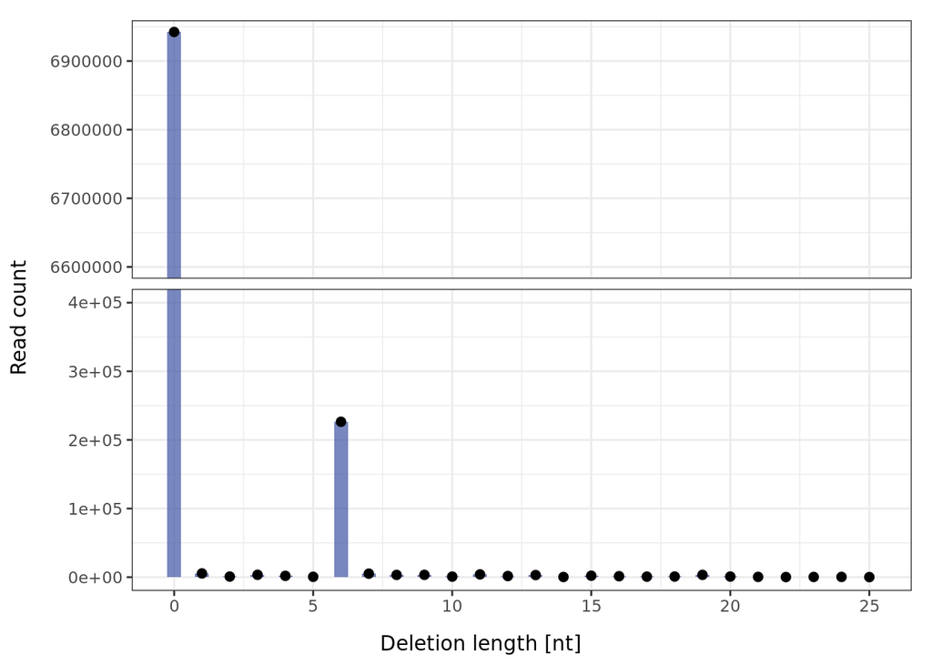

```r
library(dplyr)
library(tidyr)
library(ggplot2)
library(forcats)
library(ggpubr)
library(ggbreak)

# Load data
TFBS.del.hist.df <- readRDS("./006_OTX2_TFBS_deletion_analysis/rds/TFBS.del.hist.df.rds")

# Plot histograms

FOXA1_3.del.hist.plot <- TFBS.del.hist.df %>% filter(TFBS == "FOXA1_3") %>%
  ggplot(aes(x = del.size, y = count)) +
  geom_col(width = 0.5, fill = "#3E54A4", alpha = 0.7) + # Bars
  geom_point(size = 2, color = "black") +
  ylab("Read count") + xlab("Deletion length [nt]") +
  scale_y_break(c(0.4e6, 6600000)) + theme_bw()
FOXA1_3.del.hist.plot
```

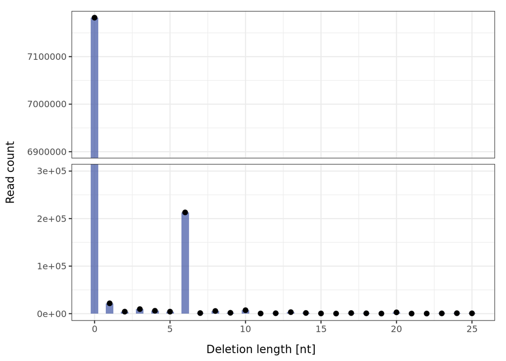

```r
FOXA1_3.del.hist.plot.2 <- TFBS.del.hist.df %>% filter(TFBS == "FOXA1_3") %>%
  ggplot(aes(x = del.size, y = count)) +
  geom_col(width = 0.5, fill = "#3E54A4", alpha = 0.7) + # Bars
  geom_point(size = 2, color = "black") +
  ylab("Read count") + xlab("Deletion length [nt]") + ggtitle("FOXA1-3") +
  ylim(0,0.3e6) + theme_bw() + theme(aspect.ratio = 1, panel.grid.minor = element_blank())

MYB_1.del.hist.plot <- TFBS.del.hist.df %>% filter(TFBS == "MYB_1") %>%
  ggplot(aes(x = del.size, y = count)) +
  geom_col(width = 0.5, fill = "#3E54A4", alpha = 0.7) + # Bars
  geom_point(size = 2, color = "black") +
  ylab("Read count") + xlab("Deletion length [nt]") +
  scale_y_break(c(0.3e6, 6900000)) + theme_bw()
MYB_1.del.hist.plot
```

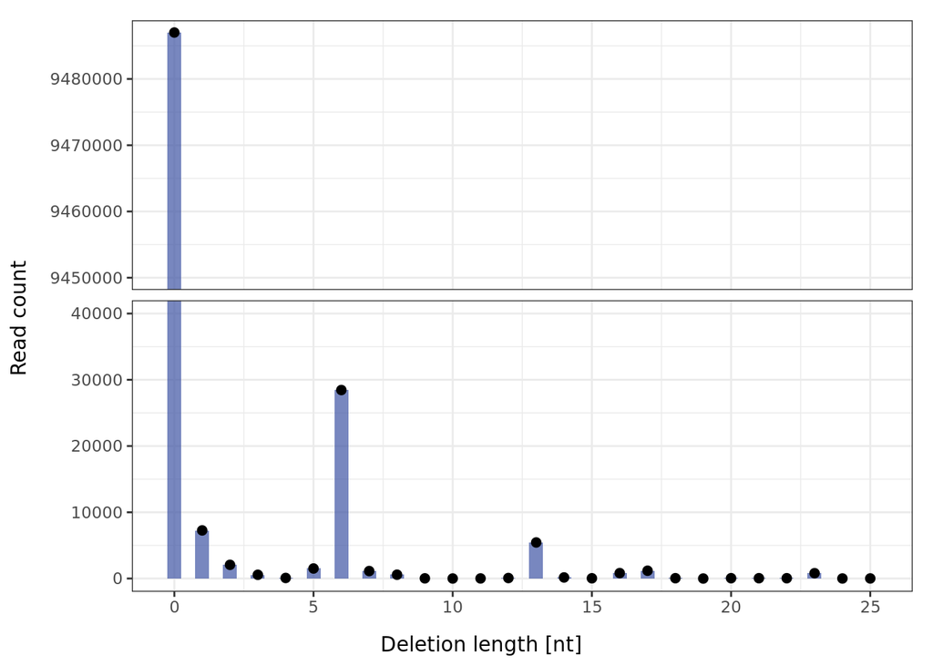

```r
MYB_1.del.hist.plot.2 <- TFBS.del.hist.df %>% filter(TFBS == "MYB_1") %>%
  ggplot(aes(x = del.size, y = count)) +
  geom_col(width = 0.5, fill = "#3E54A4", alpha = 0.7) + # Bars
  geom_point(size = 2, color = "black") +
  ylab("Read count") + xlab("Deletion length [nt]") + ggtitle("MYB-1") +
  ylim(0,0.3e6) + theme_bw() + theme(aspect.ratio = 1, panel.grid.minor = element_blank())

RFX5.del.hist.plot <- TFBS.del.hist.df %>% filter(TFBS == "RFX5") %>%
  ggplot(aes(x = del.size, y = count)) +
  geom_col(width = 0.5, fill = "#3E54A4", alpha = 0.7) + # Bars
  geom_point(size = 2, color = "black") +
  ylab("Read count") + xlab("Deletion length [nt]") +
  scale_y_break(c(40000, 9450000)) + theme_bw()
RFX5.del.hist.plot
```

```r
RFX5.del.hist.plot.2 <- TFBS.del.hist.df %>% filter(TFBS == "RFX5") %>%
  ggplot(aes(x = del.size, y = count)) +
  geom_col(width = 0.5, fill = "#3E54A4", alpha = 0.7) + # Bars
  geom_point(size = 2, color = "black") +
  ylab("Read count") + xlab("Deletion length [nt]") + ggtitle("RFX5") +
  ylim(0,40000) + theme_bw() + theme(aspect.ratio = 1, panel.grid.minor = element_blank())

# Save some representative plots

pdf("./Rplots/OTX2/TFBS.deletion.freq.at.TFBS.pdf", width=10, height=4, useDingbats=FALSE)
ggarrange(RFX5.del.hist.plot.2, FOXA1_3.del.hist.plot.2, MYB_1.del.hist.plot.2, nrow = 1)
dev.off()
```